# Stock Price Prediction Model

This report shows statistical analysis and machine learning models built to predict future stock prices using price and news data.

## 1. Introduction

History has shown that the stock market as well as economy moves repeatedly in cycles over and over. Quantitative trading has been developed to help firms build mathematical models based on expert understanding of fundamental market relationships. It enables to steer the trading system in real time and let the model learn by itself and finally execute disciplined predictive models.

The purpose of quantitative trading is to help investors decide to long/short their financial assets by estimating the future given historical infomation. For example, when surrounded by all the euphoria of a bull market, investors are inclined to feel confident and take more risks to have high returns on their assets. Thus, it can be a good strategy to revise trading strategies via forecasting the future relying on mathematics.

There are two types of data used; Price data & News data. Note that they are available to download free with some limit. For the price data, historical prices ranging from July 3rd, 2017 to June 13rd, 2018 in which 15-min intrad price data have been obtained allowing out-of-market calls. For the news data, they also have been obtained for the same time range however, data manipulation needs to be advanced since the news don't come out every 15 minutes and sometimes no information for a day or so.

## 2. Objectives and Plan

The primary objectives are to build statistical methods mostly suitable to predict stock prices using price, news, and price&news data and explain the model structure to help you understand how it gives a future value.

## 3. Model Development

Specific stocks have been chosen to see their performance. Let's first take a look at MSFT.

```
No handles with labels found to put in legend.
```

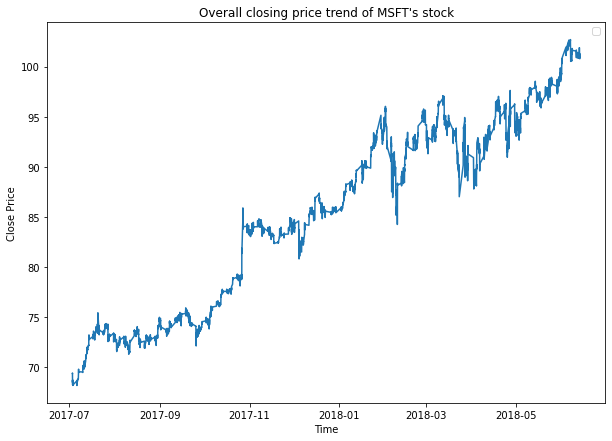

### 3.1 Ridge Regression

This is particularly useful to mitigate the problem of multicollinearity in linear regression, which commonly occurs in models with large numbers of parameters. However, in our data, the number of parameters is not large so ridge regression with one predictor would not be so desired to be used.

```
Mean squared error for future price using price data: 0.06771142284611628
True     1425
False      78
dtype: int64
Mean squared error for future price using price&news data: 0.06770674204632066
True     1425
False      78
dtype: int64
```

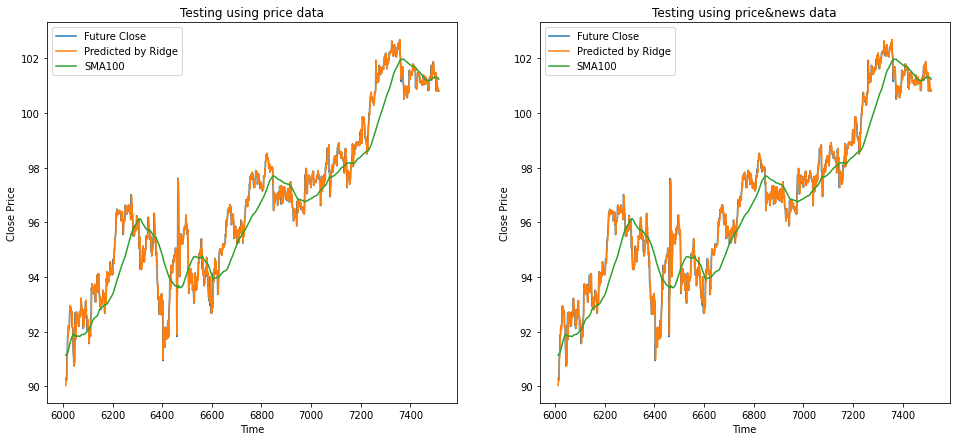

All the graphs plotted show the expected price at a low level of errors given using different set of data(i.e. price and price&news). The MSE is calculated to be relatively low and the True/False table indicates the number of observation thatt the expected price will be within an error of .5. Overall for about 94.8% of the time, this model predicts a price within a $.5 of error.

### 3.2 Random Forest

When the price is not observed in the training data but in the testing data, the predicted price would be not correct. Therefore, the percent increase for each feature is considered to calcuate the future price percent increase and then finalize it with the predicted future price for this model. With the gridsearch 5-split cross-validation random forest regressor, 400 estimators are used to predict.

```
Mean squared error for future price using price data: 0.07012419854997234
True     1427
False      76
dtype: int64
=-=-=-=-=-=-=-=-=-=-=-=-=-=-=-=-=-=-=-=-=-=-=-=-=-=-=-=-=-=-=-=-=-=
Mean squared error for future price using news data: 0.06795345570784567
True     1422
False      81
dtype: int64
=-=-=-=-=-=-=-=-=-=-=-=-=-=-=-=-=-=-=-=-=-=-=-=-=-=-=-=-=-=-=-=-=-=
Mean squared error for future price using price&news data: 0.06955547601603145
True     1425
False      78
dtype: int64
```

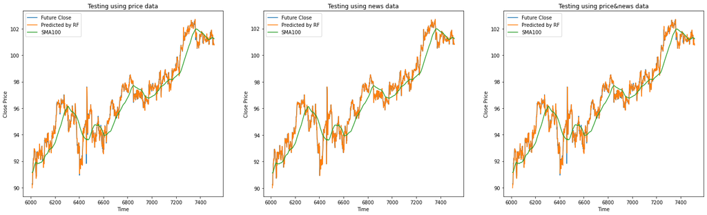

All the graphs plotted show the expected price at a low level of errors given using different set of data(i.e. price, news, and price&news). The Mean Square Error(MSE) is calculated to show the metric and the True/False table indicates the number of observation thatt the expected price will be within an error of .5. Overall for about 94.8% of the time, this model predicts a price within a $.5 of error.

### 3.3 Support Vector Machine

```
Mean squared error for future price using price data: 0.2585091324950895
True     988
False    515
dtype: int64
=-=-=-=-=-=-=-=-=-=-=-=-=-=-=-=-=-=-=-=-=-=-=-=-=-=-=-=-=-=-=-=-=-=
Mean squared error for future price using news data: 0.2585091324950895
True     988
False    515
dtype: int64
=-=-=-=-=-=-=-=-=-=-=-=-=-=-=-=-=-=-=-=-=-=-=-=-=-=-=-=-=-=-=-=-=-=
Mean squared error for future price using price&news data: 0.2585091324950895
True     988
False    515
dtype: int64
```

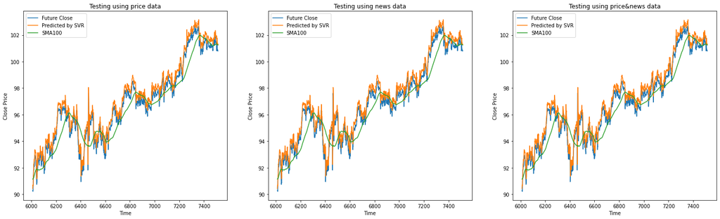

Likewise these graphs plotted above show the expected price at a low level of errors given using different set of data(i.e. price, news, and price&news). However, this model generates a littl higher value than a true value overall, which leads to a higher level of errors compared to the RF or Ridge model. The True/False table also shows that the number of observations that fall outside the range of \$.5 is greater so one can conclude that for only about 65.7\% of the time, this model predicts a price within a \$.5 of error.

### 3.4 Neural Network

#### 3.4.1 Deep Neural Network

A closing price will be predicted for a deep neural network model and compared with 100-day simple moving average(SMA) for their efficiencies.

For the structure of Deep Neural Network, it is composed by three layers with 128, 64, and 32 neurons respectively, applying the LeakyReLU acitivation for each layer in which a batch normalization was inserted to aviod the covariate shift. Also, Dropout rate of .5 is applied in order to avoid overfitting and improve the generalization power of the network. The Adam optimizer is used to minimize the mean squared error function with learning rate of .01.

$$ L(x) = {1 \over n}\sum\limits_{x=1}^{\infty} {(Y_i - \hat{Y_i})^2}$$

A hundred epochs are used to train the model and the followings are the results.

```
Model: "sequential"
_________________________________________________________________
Layer (type)                 Output Shape              Param #
=================================================================
dense (Dense)                (None, 128)               768
_________________________________________________________________
batch_normalization (BatchNo (None, 128)               512
_________________________________________________________________
dropout (Dropout)            (None, 128)               0
_________________________________________________________________
dense_1 (Dense)              (None, 64)                8256
_________________________________________________________________
batch_normalization_1 (Batch (None, 64)                256
_________________________________________________________________
dropout_1 (Dropout)          (None, 64)                0
_________________________________________________________________
dense_2 (Dense)              (None, 32)                2080
_________________________________________________________________
batch_normalization_2 (Batch (None, 32)                128
_________________________________________________________________
dropout_2 (Dropout)          (None, 32)                0
_________________________________________________________________
dense_3 (Dense)              (None, 1)                 33
=================================================================
Total params: 12,033
Trainable params: 11,585
Non-trainable params: 448
_________________________________________________________________
```

```
Mean squared error for future price using price data: 0.0680053534379009
True     1422
False      81
dtype: int64
```

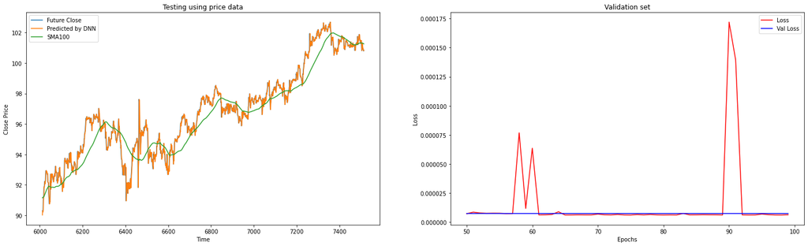

#### 3.4.2. Recurrent Neural Network

From here, let's take a little different path for data manipulation. We've been trying to predict the future closing price with a set of prices from previous time period and corresponding news data. However, I'd like to use only closing price to predict the next closing price. So, previous 100 closing prices is set to one window to estimate the next price and the window of prices steps down as the future closing price gets further. For every stock, 80% of the prices are trained and the rest will be tested for validating its model performance.

For the structure of Recurrent Neural Network, it is composed by two RNN layers with 50 neurons each applying the relu acitivation. The stochastic gradient descent optimizer is exploited to minimize the Huber loss function;

$$L_{\delta}(a) = \left\{ \begin{array}{ll} {1 \over 2}a^2 & \mbox{for } |a| \le \delta, \\ \delta(|a|-{1 \over 2}\delta) & \mbox{otherwise } \end{array} \right.$$

```
(1e-07, 0.0001, 0.0, 60.0)
```

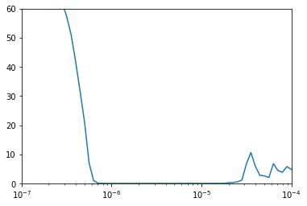

```
Mean squared error for future price using price data: 0.1274606672799516
True     1341
False     163
dtype: int64
```

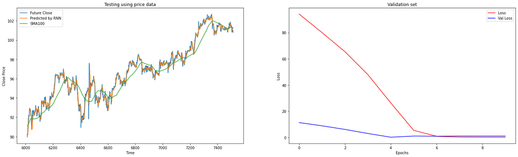

The RNN produces the expected price at a low level of errors using price data. The MSE is about .127 and the True/False table indicates that the expected price will be within an error of .5 for about 89% of the time. The loss plot on the right stop getting smaller after 6 epochs, which means that the model doesn't learm after 6 epoch much so the structure or parameters needs to be tuned.

## 4. Closing

Overall, those five Machine Learning algorithms have been developed and corresponding metrics are calculated to help to decide which algorithm to use.

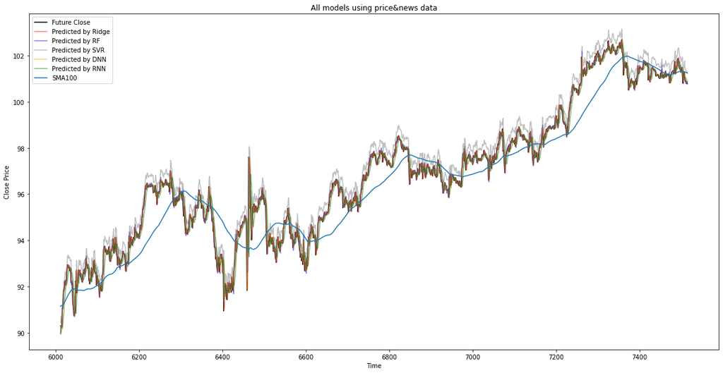